# stack_exchange

**Stack Exchange**

employs a reputation award system for its questions and answers. Each post — each question/answer — is a post that is subject to upvotes and downvotes. This ensures that good posts are easily identifiable.

Being a multidisciplinary field, there a few Stack Exchange websites there are relevant to goal here:

- Data Science
- Cross Validated — a statistics site
- Artificial Intelligence
- Mathematics
- Stack Overflow

And if want to include Data Engineering, can also consider:

- Database Administrators;
- Unix & Linux;
- Software Engineering;

**Stack Exchange**

What kind of questions are welcome on this site?

On DSSE's help center's section on questions , we can read that we should:

- Avoid subjective questions.
- Ask practical questions about Data Science — there are adequate sites for theoretical questions.
- Ask specific questions.
- Make questions relevant to others.

All of these characteristics, if employed, should be helpful attributes to our goal. In the help center we also learned that in addition to the sites mentioned in the Learn section, there are other two sites that are relevant:

- Open Data (Dataset requests)
- Computational Science (Software packages and algorithms in applied mathematics)

What, other than questions, does DSSE's home subdivide into? On the home page we can see that we have four sections:

- Questions — a list of all questions asked;
- Tags — a list of tags (keywords or labels that categorize questions);
- Users — a list of users;
- Unanswered — a list of unanswered questions;

The tagging system used by Stack Exchange looks just like what we need to solve this problem as it allow us to quantify how many questions are asked about each subject.

Something else we can learn from exploring the help center, is that Stack Exchange's sites are heavily moderated by the community; this gives us some confidence in using the tagging system to derive conclusions.

**Stack Exchange Data Explorer**

Perusing the table names, a few stand out as relevant for our goal:

- Posts
- PostTags
- Tags
- TagSynonyms

The posts table has a lot of columns. We'll be focusing our attention on those that seem relevant towards our goal:

- Id: An identification number for the post.
- PostTypeId: An identification number for the type of post.
- CreationDate: The date and time of creation of the post.
- Score: The post's score.
- ViewCount: How many times the post was viewed.
- Tags: What tags were used.
- AnswerCount: How many answers the question got (only applicable to question posts).
- FavoriteCount: How many times the question was favored (only applicable to question posts).

exception of the tags column, the last few columns contain information about how popular the post is — the kind of information we're after.

```python
import pandas as pd
import matplotlib.pyplot as plt
import seaborn as sns

%matplotlib inline
```

```python
questions = pd.read_csv('2019_questions.csv', parse_dates=['CreationDate'])
```

```python
questions.info()
```

```
<class 'pandas.core.frame.DataFrame'>
RangeIndex: 8839 entries, 0 to 8838
Data columns (total 7 columns):
Id               8839 non-null int64
CreationDate     8839 non-null datetime64[ns]
Score            8839 non-null int64
ViewCount        8839 non-null int64
Tags             8839 non-null object
AnswerCount      8839 non-null int64
FavoriteCount    1407 non-null float64
dtypes: datetime64[ns](1), float64(1), int64(4), object(1)
memory usage: 483.5+ KB
```

```python
questions.shape
```

```
(8839, 7)
```

```python
questions.isnull().sum()
```

```
Id                  0
CreationDate        0
Score               0
ViewCount           0
Tags                0
AnswerCount         0
FavoriteCount    7432
dtype: int64
```

We see that only FavoriteCount has missing values. A missing value on this column probably means that the question was is not present in any users' favorite list, so we can replace the missing values with zero.

The types seem adequate for every column, however, after we fill in the missing values on FavoriteCount, there is no reason to store the values as floats.

```python
questions["Tags"].apply(lambda value: type(value)).unique()
```

```
array([<class 'str'>], dtype=object)
```

**Cleaning the Data**

begin by fixing FavoriteCount.

```python
questions.fillna(value = {'FavoriteCount': 0}, inplace=True)
```

```python
questions['FavoriteCount'] = questions['FavoriteCount'].astype(int)
```

```python
questions.dtypes
```

```
Id                        int64
CreationDate     datetime64[ns]
Score                     int64
ViewCount                 int64
Tags                     object
AnswerCount               int64
FavoriteCount             int64
dtype: object
```

```python
questions['Tags'] = questions['Tags'].str.replace("^<|>$", "").str.split("><")
```

```python
questions.sample(5)
```

|  | Id | CreationDate | Score | ViewCount | Tags | AnswerCount | FavoriteCount |
| --- | --- | --- | --- | --- | --- | --- | --- |
| 7955 | 54612 | 2019-06-27 10:51:32 | 2 | 94 | [xgboost, marketing] | 1 | 0 |
| 5501 | 62926 | 2019-11-09 19:44:14 | 0 | 28 | [pandas, dataframe] | 1 | 0 |
| 5481 | 52063 | 2019-05-16 10:35:38 | 1 | 69 | [python, pytorch] | 1 | 0 |
| 1681 | 57497 | 2019-08-13 12:53:29 | 2 | 48 | [optimization, gradient-descent, regularization] | 1 | 0 |
| 4599 | 61899 | 2019-10-17 19:59:18 | 1 | 140 | [machine-learning, python, scikit-learn, light... | 1 | 0 |

focus is now on determining the most popular tags. Will do so by considering two different popularity proxies: for each tag will count how many times the tag was used, and how many times a question with that tag was viewed.

```python
tag_count = {}

for tags in questions['Tags']:
    for tag in tags:
        if tag in tag_count:
            tag_count[tag] += 1
        else:
            tag_count[tag] = 1
```

```python
print(tag_count)
```

```
{'jaccard-coefficient': 4, 'distributed': 7, 'apache-nifi': 1, 'dummy-variables': 19, 'forecasting': 85, 'opencv': 39, 'nosql': 3, 'open-set': 2, 'faster-rcnn': 38, 'learning-rate': 8, 'k-means': 81, 'mcmc': 4, 'helmert-coding': 1, 'cosine-distance': 21, 'orange3': 20, 'doc2vec': 3, 'least-squares-s…
```

transforming tag_count in a dataframe.

```python
tag_count = pd.DataFrame.from_dict(tag_count, orient='index')
```

```python
tag_count.rename(columns = {0: 'Count'}, inplace=True)
```

```python
tag_count.head(7)
```

|  | Count |
| --- | --- |
| jaccard-coefficient | 4 |
| distributed | 7 |
| apache-nifi | 1 |
| dummy-variables | 19 |
| forecasting | 85 |
| opencv | 39 |
| nosql | 3 |

```python
most_used = tag_count.sort_values(by='Count', ascending=False)
```

```python
most_used
```

|  | Count |
| --- | --- |
| machine-learning | 2693 |
| python | 1814 |
| deep-learning | 1220 |
| neural-network | 1055 |
| keras | 935 |
| classification | 685 |
| tensorflow | 584 |
| scikit-learn | 540 |
| nlp | 493 |
| cnn | 489 |
| time-series | 466 |
| lstm | 402 |
| pandas | 354 |
| regression | 347 |
| dataset | 340 |
| r | 268 |
| predictive-modeling | 265 |
| clustering | 257 |
| statistics | 234 |
| machine-learning-model | 224 |
| data-mining | 217 |
| data | 213 |
| image-classification | 211 |
| feature-selection | 209 |
| reinforcement-learning | 203 |
| data-science-model | 186 |
| linear-regression | 175 |
| pytorch | 175 |
| xgboost | 165 |
| feature-engineering | 163 |
| ... | ... |
| hog | 1 |
| haar-cascade | 1 |
| normal-equation | 1 |
| encoder | 1 |
| noisification | 1 |
| spearmans-rank-correlation | 1 |
| google-cloud | 1 |
| dump | 1 |
| parquet | 1 |
| 3d-object-detection | 1 |
| frequentist | 1 |
| gru | 1 |
| amazon-ml | 1 |
| open-source | 1 |
| multivariate-distribution | 1 |
| paperspace | 1 |
| cause-effect-relations | 1 |
| redshift | 1 |
| adaboost | 1 |
| .net | 1 |
| nl2sql | 1 |
| corpus | 1 |
| unseen-data | 1 |
| hurdle-model | 1 |
| exploitation | 1 |
| impala | 1 |
| proximal-svm | 1 |
| consumerweb | 1 |
| rmsle | 1 |
| community | 1 |

526 rows × 1 columns

```python
most_used_top_25 = most_used.head(25)
```

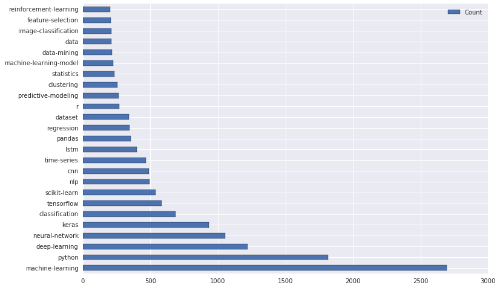

```python
most_used_top_25.plot(kind="barh", figsize=(12,8))
```

```python
tag_view_count = dict()

for index, row in questions.iterrows():
    for tag in row['Tags']:
        if tag in tag_view_count:
            tag_view_count[tag] += row['ViewCount']
        else:
            tag_view_count[tag] = row['ViewCount']
```

```python
tag_view_count
```

```
{'.net': 438,
 '3d-object-detection': 7,
 '3d-reconstruction': 1129,
 'ab-test': 153,
 'accuracy': 15233,
 'activation': 15,
 'activation-function': 13121,
 'active-learning': 155,
 'activity-recognition': 126,
 'actor-critic': 1014,
 'adaboost': 23,
 'aggregation': 828,
 'ai': 3432,
 'alex-net': 208,
 'algorithms': 4581,
 'allennlp': 183,
 'amazon-ml': 35,
 'anaconda': 10476,
 'ann': 74,
 'annotation': 1043,
 'anomaly': 352,
 'anomaly-detection': 10992,
 'anonymization': 381,
 'anova': 70,
 'apache-hadoop': 466,
 'apache-nifi': 119,
 'apache-spark': 4598,
 'arima': 1004,
 'association-rules': 1022,
 'attention-mechanism': 15165,
 'auc': 67,
 'audio-recognition': 2195,
 'autoencoder': 15676,
 'automatic-summarization': 581,
 'automation': 142,
 'automl': 85,
 'aws': 1939,
 'aws-lambda': 992,
 'azure-ml': 694,
 'backpropagation': 9958,
```

[output cut: 471 more lines]

```
 'version-control': 94,
 'vgg16': 2643,
 'visualization': 18953,
 'web-scrapping': 292,
 'weight-initialization': 440,
 'weighted-data': 2664,
 'weka': 1068,
 'wikipedia': 23,
 'wolfram-language': 286,
 'word': 130,
 'word-embeddings': 18632,
 'word2vec': 15979,
 'xboost': 71,
 'xgboost': 31533,
 'yolo': 3735}
```

```python
tag_view_count = pd.DataFrame.from_dict(tag_view_count, orient="index")
tag_view_count.rename(columns={0: "ViewCount"}, inplace=True)
```

```python
tag_view_count.head()
```

|  | ViewCount |
| --- | --- |
| jaccard-coefficient | 634 |
| distributed | 227 |
| apache-nifi | 119 |
| dummy-variables | 3775 |
| forecasting | 8797 |

```python
most_viewed = tag_view_count.sort_values(by="ViewCount", ascending=False)
```

```python
most_viewed
```

|  | ViewCount |
| --- | --- |
| python | 537585 |
| machine-learning | 388499 |
| keras | 268608 |
| deep-learning | 233628 |
| pandas | 201787 |
| neural-network | 185367 |
| scikit-learn | 128110 |
| tensorflow | 121369 |
| classification | 104457 |
| dataframe | 89352 |
| lstm | 74458 |
| nlp | 71382 |
| cnn | 70349 |
| time-series | 64134 |
| numpy | 49767 |
| regression | 49451 |
| dataset | 43151 |
| pytorch | 40240 |
| csv | 38654 |
| clustering | 33928 |
| r | 33684 |
| image-classification | 33238 |
| computer-vision | 32502 |
| seaborn | 32244 |
| xgboost | 31533 |
| data-mining | 31056 |
| feature-selection | 29128 |
| bert | 28874 |
| data-formats | 28644 |
| data-cleaning | 27529 |
| ... | ... |
| dump | 23 |
| open-source | 21 |
| history | 20 |
| redshift | 19 |
| pgm | 19 |
| google-cloud | 19 |
| impala | 19 |
| hog | 18 |
| rmse | 17 |
| parquet | 17 |
| rmsle | 17 |
| state-of-the-art | 17 |
| encoder | 16 |
| gru | 16 |
| haar-cascade | 16 |
| activation | 15 |
| rdkit | 15 |
| nl2sql | 14 |
| hurdle-model | 12 |
| exploitation | 12 |
| marginal-effects | 12 |
| data-transfer | 12 |
| paperspace | 12 |
| frequentist | 11 |
| non-convex | 11 |
| noisification | 9 |
| statsmodels | 9 |
| kitti-dataset | 7 |
| 3d-object-detection | 7 |
| multivariate-distribution | 4 |

526 rows × 1 columns

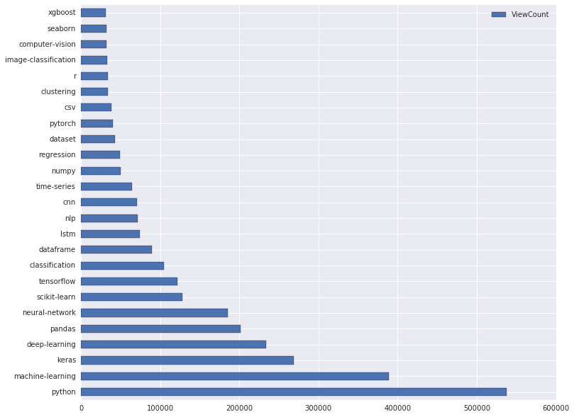

```python
most_viewed_top_25 = most_viewed.head(25)
most_viewed_top_25.plot(kind="barh", figsize=(12,10))
```

[output not shown]

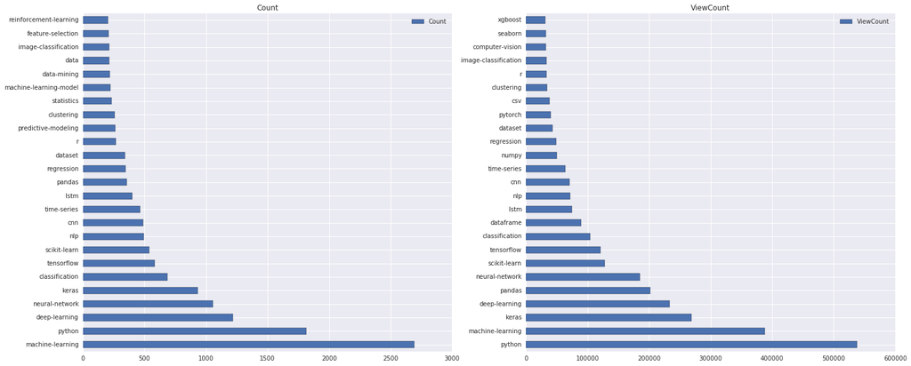

```python
fig, axes = plt.subplots(nrows=1, ncols=2)
fig.set_size_inches((24, 10))
most_used_top_25.plot(kind="barh", ax=axes[0], subplots=True)
most_viewed_top_25.plot(kind="barh", ax=axes[1], subplots=True)
```

```python
in_used = pd.merge(most_used, most_viewed, how="left", left_index=True, right_index=True)
in_viewed = pd.merge(most_used, most_viewed, how="right", left_index=True, right_index=True)
```

```python
in_used.head(5)
```

|  | Count | ViewCount |
| --- | --- | --- |
| machine-learning | 2693 | 388499 |
| python | 1814 | 537585 |
| deep-learning | 1220 | 233628 |
| neural-network | 1055 | 185367 |
| keras | 935 | 268608 |

```python
in_viewed.head(5)
```

|  | Count | ViewCount |
| --- | --- | --- |
| python | 1814 | 537585 |
| machine-learning | 2693 | 388499 |
| keras | 935 | 268608 |
| deep-learning | 1220 | 233628 |
| pandas | 354 | 201787 |

**Relations Between Tags**

One way of trying to gauge how pairs of tags are related to each other, is to count how many times each pair appears together.

```python
all_tags = list(tag_count.index)
all_tags
```

```
['jaccard-coefficient',
 'distributed',
 'apache-nifi',
 'dummy-variables',
 'forecasting',
 'opencv',
 'nosql',
 'open-set',
 'faster-rcnn',
 'learning-rate',
 'k-means',
 'mcmc',
 'helmert-coding',
 'cosine-distance',
 'orange3',
 'doc2vec',
 'least-squares-svm',
 'object-recognition',
 'huggingface',
 'web-scrapping',
 'missing-data',
 'powerbi',
 'pruning',
 'predictor-importance',
 'sports',
 'scipy',
 'parallel',
 'clustering',
 'reinforcement-learning',
 'ipython',
 'data-science-model',
 'anomaly-detection',
 'machine-learning',
 'encoding',
 'learning',
 'python',
 'metric',
 'data-formats',
 'java',
 'experiments',
```

[output cut: 471 more lines]

```
 'reference-request',
 'bioinformatics',
 'bayesian-networks',
 'imbalanced-learn',
 'dbscan',
 'text-filter',
 'c++',
 'tokenization',
 'activation-function',
 'historgram',
 'cnn',
 'dynamic-programming',
 'ridge-regression',
 'counts',
 'tools']
```

```python
associations = pd.DataFrame(index=all_tags, columns=all_tags)
```

```python
associations
```

|  | jaccard-coefficient | distributed | apache-nifi | dummy-variables | forecasting | opencv | nosql | open-set | faster-rcnn | learning-rate | ... | text-filter | c++ | tokenization | activation-function | historgram | cnn | dynamic-programming | ridge-regression | counts | tools |
| --- | --- | --- | --- | --- | --- | --- | --- | --- | --- | --- | --- | --- | --- | --- | --- | --- | --- | --- | --- | --- | --- |
| jaccard-coefficient | NaN | NaN | NaN | NaN | NaN | NaN | NaN | NaN | NaN | NaN | ... | NaN | NaN | NaN | NaN | NaN | NaN | NaN | NaN | NaN | NaN |
| distributed | NaN | NaN | NaN | NaN | NaN | NaN | NaN | NaN | NaN | NaN | ... | NaN | NaN | NaN | NaN | NaN | NaN | NaN | NaN | NaN | NaN |
| apache-nifi | NaN | NaN | NaN | NaN | NaN | NaN | NaN | NaN | NaN | NaN | ... | NaN | NaN | NaN | NaN | NaN | NaN | NaN | NaN | NaN | NaN |
| dummy-variables | NaN | NaN | NaN | NaN | NaN | NaN | NaN | NaN | NaN | NaN | ... | NaN | NaN | NaN | NaN | NaN | NaN | NaN | NaN | NaN | NaN |
| forecasting | NaN | NaN | NaN | NaN | NaN | NaN | NaN | NaN | NaN | NaN | ... | NaN | NaN | NaN | NaN | NaN | NaN | NaN | NaN | NaN | NaN |
| opencv | NaN | NaN | NaN | NaN | NaN | NaN | NaN | NaN | NaN | NaN | ... | NaN | NaN | NaN | NaN | NaN | NaN | NaN | NaN | NaN | NaN |
| nosql | NaN | NaN | NaN | NaN | NaN | NaN | NaN | NaN | NaN | NaN | ... | NaN | NaN | NaN | NaN | NaN | NaN | NaN | NaN | NaN | NaN |
| open-set | NaN | NaN | NaN | NaN | NaN | NaN | NaN | NaN | NaN | NaN | ... | NaN | NaN | NaN | NaN | NaN | NaN | NaN | NaN | NaN | NaN |
| faster-rcnn | NaN | NaN | NaN | NaN | NaN | NaN | NaN | NaN | NaN | NaN | ... | NaN | NaN | NaN | NaN | NaN | NaN | NaN | NaN | NaN | NaN |
| learning-rate | NaN | NaN | NaN | NaN | NaN | NaN | NaN | NaN | NaN | NaN | ... | NaN | NaN | NaN | NaN | NaN | NaN | NaN | NaN | NaN | NaN |
| k-means | NaN | NaN | NaN | NaN | NaN | NaN | NaN | NaN | NaN | NaN | ... | NaN | NaN | NaN | NaN | NaN | NaN | NaN | NaN | NaN | NaN |
| mcmc | NaN | NaN | NaN | NaN | NaN | NaN | NaN | NaN | NaN | NaN | ... | NaN | NaN | NaN | NaN | NaN | NaN | NaN | NaN | NaN | NaN |
| helmert-coding | NaN | NaN | NaN | NaN | NaN | NaN | NaN | NaN | NaN | NaN | ... | NaN | NaN | NaN | NaN | NaN | NaN | NaN | NaN | NaN | NaN |
| cosine-distance | NaN | NaN | NaN | NaN | NaN | NaN | NaN | NaN | NaN | NaN | ... | NaN | NaN | NaN | NaN | NaN | NaN | NaN | NaN | NaN | NaN |
| orange3 | NaN | NaN | NaN | NaN | NaN | NaN | NaN | NaN | NaN | NaN | ... | NaN | NaN | NaN | NaN | NaN | NaN | NaN | NaN | NaN | NaN |
| doc2vec | NaN | NaN | NaN | NaN | NaN | NaN | NaN | NaN | NaN | NaN | ... | NaN | NaN | NaN | NaN | NaN | NaN | NaN | NaN | NaN | NaN |
| least-squares-svm | NaN | NaN | NaN | NaN | NaN | NaN | NaN | NaN | NaN | NaN | ... | NaN | NaN | NaN | NaN | NaN | NaN | NaN | NaN | NaN | NaN |
| object-recognition | NaN | NaN | NaN | NaN | NaN | NaN | NaN | NaN | NaN | NaN | ... | NaN | NaN | NaN | NaN | NaN | NaN | NaN | NaN | NaN | NaN |
| huggingface | NaN | NaN | NaN | NaN | NaN | NaN | NaN | NaN | NaN | NaN | ... | NaN | NaN | NaN | NaN | NaN | NaN | NaN | NaN | NaN | NaN |
| web-scrapping | NaN | NaN | NaN | NaN | NaN | NaN | NaN | NaN | NaN | NaN | ... | NaN | NaN | NaN | NaN | NaN | NaN | NaN | NaN | NaN | NaN |
| missing-data | NaN | NaN | NaN | NaN | NaN | NaN | NaN | NaN | NaN | NaN | ... | NaN | NaN | NaN | NaN | NaN | NaN | NaN | NaN | NaN | NaN |
| powerbi | NaN | NaN | NaN | NaN | NaN | NaN | NaN | NaN | NaN | NaN | ... | NaN | NaN | NaN | NaN | NaN | NaN | NaN | NaN | NaN | NaN |
| pruning | NaN | NaN | NaN | NaN | NaN | NaN | NaN | NaN | NaN | NaN | ... | NaN | NaN | NaN | NaN | NaN | NaN | NaN | NaN | NaN | NaN |
| predictor-importance | NaN | NaN | NaN | NaN | NaN | NaN | NaN | NaN | NaN | NaN | ... | NaN | NaN | NaN | NaN | NaN | NaN | NaN | NaN | NaN | NaN |
| sports | NaN | NaN | NaN | NaN | NaN | NaN | NaN | NaN | NaN | NaN | ... | NaN | NaN | NaN | NaN | NaN | NaN | NaN | NaN | NaN | NaN |
| scipy | NaN | NaN | NaN | NaN | NaN | NaN | NaN | NaN | NaN | NaN | ... | NaN | NaN | NaN | NaN | NaN | NaN | NaN | NaN | NaN | NaN |
| parallel | NaN | NaN | NaN | NaN | NaN | NaN | NaN | NaN | NaN | NaN | ... | NaN | NaN | NaN | NaN | NaN | NaN | NaN | NaN | NaN | NaN |
| clustering | NaN | NaN | NaN | NaN | NaN | NaN | NaN | NaN | NaN | NaN | ... | NaN | NaN | NaN | NaN | NaN | NaN | NaN | NaN | NaN | NaN |
| reinforcement-learning | NaN | NaN | NaN | NaN | NaN | NaN | NaN | NaN | NaN | NaN | ... | NaN | NaN | NaN | NaN | NaN | NaN | NaN | NaN | NaN | NaN |
| ipython | NaN | NaN | NaN | NaN | NaN | NaN | NaN | NaN | NaN | NaN | ... | NaN | NaN | NaN | NaN | NaN | NaN | NaN | NaN | NaN | NaN |
| ... | ... | ... | ... | ... | ... | ... | ... | ... | ... | ... | ... | ... | ... | ... | ... | ... | ... | ... | ... | ... | ... |
| rnn | NaN | NaN | NaN | NaN | NaN | NaN | NaN | NaN | NaN | NaN | ... | NaN | NaN | NaN | NaN | NaN | NaN | NaN | NaN | NaN | NaN |
| data-product | NaN | NaN | NaN | NaN | NaN | NaN | NaN | NaN | NaN | NaN | ... | NaN | NaN | NaN | NaN | NaN | NaN | NaN | NaN | NaN | NaN |
| fastai | NaN | NaN | NaN | NaN | NaN | NaN | NaN | NaN | NaN | NaN | ... | NaN | NaN | NaN | NaN | NaN | NaN | NaN | NaN | NaN | NaN |
| smote | NaN | NaN | NaN | NaN | NaN | NaN | NaN | NaN | NaN | NaN | ... | NaN | NaN | NaN | NaN | NaN | NaN | NaN | NaN | NaN | NaN |
| crawling | NaN | NaN | NaN | NaN | NaN | NaN | NaN | NaN | NaN | NaN | ... | NaN | NaN | NaN | NaN | NaN | NaN | NaN | NaN | NaN | NaN |
| performance | NaN | NaN | NaN | NaN | NaN | NaN | NaN | NaN | NaN | NaN | ... | NaN | NaN | NaN | NaN | NaN | NaN | NaN | NaN | NaN | NaN |
| refit-model | NaN | NaN | NaN | NaN | NaN | NaN | NaN | NaN | NaN | NaN | ... | NaN | NaN | NaN | NaN | NaN | NaN | NaN | NaN | NaN | NaN |
| indexing | NaN | NaN | NaN | NaN | NaN | NaN | NaN | NaN | NaN | NaN | ... | NaN | NaN | NaN | NaN | NaN | NaN | NaN | NaN | NaN | NaN |
| reshape | NaN | NaN | NaN | NaN | NaN | NaN | NaN | NaN | NaN | NaN | ... | NaN | NaN | NaN | NaN | NaN | NaN | NaN | NaN | NaN | NaN |
| data-stream-mining | NaN | NaN | NaN | NaN | NaN | NaN | NaN | NaN | NaN | NaN | ... | NaN | NaN | NaN | NaN | NaN | NaN | NaN | NaN | NaN | NaN |
| batch-normalization | NaN | NaN | NaN | NaN | NaN | NaN | NaN | NaN | NaN | NaN | ... | NaN | NaN | NaN | NaN | NaN | NaN | NaN | NaN | NaN | NaN |
| label-flipping | NaN | NaN | NaN | NaN | NaN | NaN | NaN | NaN | NaN | NaN | ... | NaN | NaN | NaN | NaN | NaN | NaN | NaN | NaN | NaN | NaN |
| vgg16 | NaN | NaN | NaN | NaN | NaN | NaN | NaN | NaN | NaN | NaN | ... | NaN | NaN | NaN | NaN | NaN | NaN | NaN | NaN | NaN | NaN |
| lbp | NaN | NaN | NaN | NaN | NaN | NaN | NaN | NaN | NaN | NaN | ... | NaN | NaN | NaN | NaN | NaN | NaN | NaN | NaN | NaN | NaN |
| nn | NaN | NaN | NaN | NaN | NaN | NaN | NaN | NaN | NaN | NaN | ... | NaN | NaN | NaN | NaN | NaN | NaN | NaN | NaN | NaN | NaN |
| reference-request | NaN | NaN | NaN | NaN | NaN | NaN | NaN | NaN | NaN | NaN | ... | NaN | NaN | NaN | NaN | NaN | NaN | NaN | NaN | NaN | NaN |
| bioinformatics | NaN | NaN | NaN | NaN | NaN | NaN | NaN | NaN | NaN | NaN | ... | NaN | NaN | NaN | NaN | NaN | NaN | NaN | NaN | NaN | NaN |
| bayesian-networks | NaN | NaN | NaN | NaN | NaN | NaN | NaN | NaN | NaN | NaN | ... | NaN | NaN | NaN | NaN | NaN | NaN | NaN | NaN | NaN | NaN |
| imbalanced-learn | NaN | NaN | NaN | NaN | NaN | NaN | NaN | NaN | NaN | NaN | ... | NaN | NaN | NaN | NaN | NaN | NaN | NaN | NaN | NaN | NaN |
| dbscan | NaN | NaN | NaN | NaN | NaN | NaN | NaN | NaN | NaN | NaN | ... | NaN | NaN | NaN | NaN | NaN | NaN | NaN | NaN | NaN | NaN |
| text-filter | NaN | NaN | NaN | NaN | NaN | NaN | NaN | NaN | NaN | NaN | ... | NaN | NaN | NaN | NaN | NaN | NaN | NaN | NaN | NaN | NaN |
| c++ | NaN | NaN | NaN | NaN | NaN | NaN | NaN | NaN | NaN | NaN | ... | NaN | NaN | NaN | NaN | NaN | NaN | NaN | NaN | NaN | NaN |
| tokenization | NaN | NaN | NaN | NaN | NaN | NaN | NaN | NaN | NaN | NaN | ... | NaN | NaN | NaN | NaN | NaN | NaN | NaN | NaN | NaN | NaN |
| activation-function | NaN | NaN | NaN | NaN | NaN | NaN | NaN | NaN | NaN | NaN | ... | NaN | NaN | NaN | NaN | NaN | NaN | NaN | NaN | NaN | NaN |
| historgram | NaN | NaN | NaN | NaN | NaN | NaN | NaN | NaN | NaN | NaN | ... | NaN | NaN | NaN | NaN | NaN | NaN | NaN | NaN | NaN | NaN |
| cnn | NaN | NaN | NaN | NaN | NaN | NaN | NaN | NaN | NaN | NaN | ... | NaN | NaN | NaN | NaN | NaN | NaN | NaN | NaN | NaN | NaN |
| dynamic-programming | NaN | NaN | NaN | NaN | NaN | NaN | NaN | NaN | NaN | NaN | ... | NaN | NaN | NaN | NaN | NaN | NaN | NaN | NaN | NaN | NaN |
| ridge-regression | NaN | NaN | NaN | NaN | NaN | NaN | NaN | NaN | NaN | NaN | ... | NaN | NaN | NaN | NaN | NaN | NaN | NaN | NaN | NaN | NaN |
| counts | NaN | NaN | NaN | NaN | NaN | NaN | NaN | NaN | NaN | NaN | ... | NaN | NaN | NaN | NaN | NaN | NaN | NaN | NaN | NaN | NaN |
| tools | NaN | NaN | NaN | NaN | NaN | NaN | NaN | NaN | NaN | NaN | ... | NaN | NaN | NaN | NaN | NaN | NaN | NaN | NaN | NaN | NaN |

526 rows × 526 columns

```python
associations.fillna(0, inplace=True)
associations
```

|  | jaccard-coefficient | distributed | apache-nifi | dummy-variables | forecasting | opencv | nosql | open-set | faster-rcnn | learning-rate | ... | text-filter | c++ | tokenization | activation-function | historgram | cnn | dynamic-programming | ridge-regression | counts | tools |
| --- | --- | --- | --- | --- | --- | --- | --- | --- | --- | --- | --- | --- | --- | --- | --- | --- | --- | --- | --- | --- | --- |
| jaccard-coefficient | 0 | 0 | 0 | 0 | 0 | 0 | 0 | 0 | 0 | 0 | ... | 0 | 0 | 0 | 0 | 0 | 0 | 0 | 0 | 0 | 0 |
| distributed | 0 | 0 | 0 | 0 | 0 | 0 | 0 | 0 | 0 | 0 | ... | 0 | 0 | 0 | 0 | 0 | 0 | 0 | 0 | 0 | 0 |
| apache-nifi | 0 | 0 | 0 | 0 | 0 | 0 | 0 | 0 | 0 | 0 | ... | 0 | 0 | 0 | 0 | 0 | 0 | 0 | 0 | 0 | 0 |
| dummy-variables | 0 | 0 | 0 | 0 | 0 | 0 | 0 | 0 | 0 | 0 | ... | 0 | 0 | 0 | 0 | 0 | 0 | 0 | 0 | 0 | 0 |
| forecasting | 0 | 0 | 0 | 0 | 0 | 0 | 0 | 0 | 0 | 0 | ... | 0 | 0 | 0 | 0 | 0 | 0 | 0 | 0 | 0 | 0 |
| opencv | 0 | 0 | 0 | 0 | 0 | 0 | 0 | 0 | 0 | 0 | ... | 0 | 0 | 0 | 0 | 0 | 0 | 0 | 0 | 0 | 0 |
| nosql | 0 | 0 | 0 | 0 | 0 | 0 | 0 | 0 | 0 | 0 | ... | 0 | 0 | 0 | 0 | 0 | 0 | 0 | 0 | 0 | 0 |
| open-set | 0 | 0 | 0 | 0 | 0 | 0 | 0 | 0 | 0 | 0 | ... | 0 | 0 | 0 | 0 | 0 | 0 | 0 | 0 | 0 | 0 |
| faster-rcnn | 0 | 0 | 0 | 0 | 0 | 0 | 0 | 0 | 0 | 0 | ... | 0 | 0 | 0 | 0 | 0 | 0 | 0 | 0 | 0 | 0 |
| learning-rate | 0 | 0 | 0 | 0 | 0 | 0 | 0 | 0 | 0 | 0 | ... | 0 | 0 | 0 | 0 | 0 | 0 | 0 | 0 | 0 | 0 |
| k-means | 0 | 0 | 0 | 0 | 0 | 0 | 0 | 0 | 0 | 0 | ... | 0 | 0 | 0 | 0 | 0 | 0 | 0 | 0 | 0 | 0 |
| mcmc | 0 | 0 | 0 | 0 | 0 | 0 | 0 | 0 | 0 | 0 | ... | 0 | 0 | 0 | 0 | 0 | 0 | 0 | 0 | 0 | 0 |
| helmert-coding | 0 | 0 | 0 | 0 | 0 | 0 | 0 | 0 | 0 | 0 | ... | 0 | 0 | 0 | 0 | 0 | 0 | 0 | 0 | 0 | 0 |
| cosine-distance | 0 | 0 | 0 | 0 | 0 | 0 | 0 | 0 | 0 | 0 | ... | 0 | 0 | 0 | 0 | 0 | 0 | 0 | 0 | 0 | 0 |
| orange3 | 0 | 0 | 0 | 0 | 0 | 0 | 0 | 0 | 0 | 0 | ... | 0 | 0 | 0 | 0 | 0 | 0 | 0 | 0 | 0 | 0 |
| doc2vec | 0 | 0 | 0 | 0 | 0 | 0 | 0 | 0 | 0 | 0 | ... | 0 | 0 | 0 | 0 | 0 | 0 | 0 | 0 | 0 | 0 |
| least-squares-svm | 0 | 0 | 0 | 0 | 0 | 0 | 0 | 0 | 0 | 0 | ... | 0 | 0 | 0 | 0 | 0 | 0 | 0 | 0 | 0 | 0 |
| object-recognition | 0 | 0 | 0 | 0 | 0 | 0 | 0 | 0 | 0 | 0 | ... | 0 | 0 | 0 | 0 | 0 | 0 | 0 | 0 | 0 | 0 |
| huggingface | 0 | 0 | 0 | 0 | 0 | 0 | 0 | 0 | 0 | 0 | ... | 0 | 0 | 0 | 0 | 0 | 0 | 0 | 0 | 0 | 0 |
| web-scrapping | 0 | 0 | 0 | 0 | 0 | 0 | 0 | 0 | 0 | 0 | ... | 0 | 0 | 0 | 0 | 0 | 0 | 0 | 0 | 0 | 0 |
| missing-data | 0 | 0 | 0 | 0 | 0 | 0 | 0 | 0 | 0 | 0 | ... | 0 | 0 | 0 | 0 | 0 | 0 | 0 | 0 | 0 | 0 |
| powerbi | 0 | 0 | 0 | 0 | 0 | 0 | 0 | 0 | 0 | 0 | ... | 0 | 0 | 0 | 0 | 0 | 0 | 0 | 0 | 0 | 0 |
| pruning | 0 | 0 | 0 | 0 | 0 | 0 | 0 | 0 | 0 | 0 | ... | 0 | 0 | 0 | 0 | 0 | 0 | 0 | 0 | 0 | 0 |
| predictor-importance | 0 | 0 | 0 | 0 | 0 | 0 | 0 | 0 | 0 | 0 | ... | 0 | 0 | 0 | 0 | 0 | 0 | 0 | 0 | 0 | 0 |
| sports | 0 | 0 | 0 | 0 | 0 | 0 | 0 | 0 | 0 | 0 | ... | 0 | 0 | 0 | 0 | 0 | 0 | 0 | 0 | 0 | 0 |
| scipy | 0 | 0 | 0 | 0 | 0 | 0 | 0 | 0 | 0 | 0 | ... | 0 | 0 | 0 | 0 | 0 | 0 | 0 | 0 | 0 | 0 |
| parallel | 0 | 0 | 0 | 0 | 0 | 0 | 0 | 0 | 0 | 0 | ... | 0 | 0 | 0 | 0 | 0 | 0 | 0 | 0 | 0 | 0 |
| clustering | 0 | 0 | 0 | 0 | 0 | 0 | 0 | 0 | 0 | 0 | ... | 0 | 0 | 0 | 0 | 0 | 0 | 0 | 0 | 0 | 0 |
| reinforcement-learning | 0 | 0 | 0 | 0 | 0 | 0 | 0 | 0 | 0 | 0 | ... | 0 | 0 | 0 | 0 | 0 | 0 | 0 | 0 | 0 | 0 |
| ipython | 0 | 0 | 0 | 0 | 0 | 0 | 0 | 0 | 0 | 0 | ... | 0 | 0 | 0 | 0 | 0 | 0 | 0 | 0 | 0 | 0 |
| ... | ... | ... | ... | ... | ... | ... | ... | ... | ... | ... | ... | ... | ... | ... | ... | ... | ... | ... | ... | ... | ... |
| rnn | 0 | 0 | 0 | 0 | 0 | 0 | 0 | 0 | 0 | 0 | ... | 0 | 0 | 0 | 0 | 0 | 0 | 0 | 0 | 0 | 0 |
| data-product | 0 | 0 | 0 | 0 | 0 | 0 | 0 | 0 | 0 | 0 | ... | 0 | 0 | 0 | 0 | 0 | 0 | 0 | 0 | 0 | 0 |
| fastai | 0 | 0 | 0 | 0 | 0 | 0 | 0 | 0 | 0 | 0 | ... | 0 | 0 | 0 | 0 | 0 | 0 | 0 | 0 | 0 | 0 |
| smote | 0 | 0 | 0 | 0 | 0 | 0 | 0 | 0 | 0 | 0 | ... | 0 | 0 | 0 | 0 | 0 | 0 | 0 | 0 | 0 | 0 |
| crawling | 0 | 0 | 0 | 0 | 0 | 0 | 0 | 0 | 0 | 0 | ... | 0 | 0 | 0 | 0 | 0 | 0 | 0 | 0 | 0 | 0 |
| performance | 0 | 0 | 0 | 0 | 0 | 0 | 0 | 0 | 0 | 0 | ... | 0 | 0 | 0 | 0 | 0 | 0 | 0 | 0 | 0 | 0 |
| refit-model | 0 | 0 | 0 | 0 | 0 | 0 | 0 | 0 | 0 | 0 | ... | 0 | 0 | 0 | 0 | 0 | 0 | 0 | 0 | 0 | 0 |
| indexing | 0 | 0 | 0 | 0 | 0 | 0 | 0 | 0 | 0 | 0 | ... | 0 | 0 | 0 | 0 | 0 | 0 | 0 | 0 | 0 | 0 |
| reshape | 0 | 0 | 0 | 0 | 0 | 0 | 0 | 0 | 0 | 0 | ... | 0 | 0 | 0 | 0 | 0 | 0 | 0 | 0 | 0 | 0 |
| data-stream-mining | 0 | 0 | 0 | 0 | 0 | 0 | 0 | 0 | 0 | 0 | ... | 0 | 0 | 0 | 0 | 0 | 0 | 0 | 0 | 0 | 0 |
| batch-normalization | 0 | 0 | 0 | 0 | 0 | 0 | 0 | 0 | 0 | 0 | ... | 0 | 0 | 0 | 0 | 0 | 0 | 0 | 0 | 0 | 0 |
| label-flipping | 0 | 0 | 0 | 0 | 0 | 0 | 0 | 0 | 0 | 0 | ... | 0 | 0 | 0 | 0 | 0 | 0 | 0 | 0 | 0 | 0 |
| vgg16 | 0 | 0 | 0 | 0 | 0 | 0 | 0 | 0 | 0 | 0 | ... | 0 | 0 | 0 | 0 | 0 | 0 | 0 | 0 | 0 | 0 |
| lbp | 0 | 0 | 0 | 0 | 0 | 0 | 0 | 0 | 0 | 0 | ... | 0 | 0 | 0 | 0 | 0 | 0 | 0 | 0 | 0 | 0 |
| nn | 0 | 0 | 0 | 0 | 0 | 0 | 0 | 0 | 0 | 0 | ... | 0 | 0 | 0 | 0 | 0 | 0 | 0 | 0 | 0 | 0 |
| reference-request | 0 | 0 | 0 | 0 | 0 | 0 | 0 | 0 | 0 | 0 | ... | 0 | 0 | 0 | 0 | 0 | 0 | 0 | 0 | 0 | 0 |
| bioinformatics | 0 | 0 | 0 | 0 | 0 | 0 | 0 | 0 | 0 | 0 | ... | 0 | 0 | 0 | 0 | 0 | 0 | 0 | 0 | 0 | 0 |
| bayesian-networks | 0 | 0 | 0 | 0 | 0 | 0 | 0 | 0 | 0 | 0 | ... | 0 | 0 | 0 | 0 | 0 | 0 | 0 | 0 | 0 | 0 |
| imbalanced-learn | 0 | 0 | 0 | 0 | 0 | 0 | 0 | 0 | 0 | 0 | ... | 0 | 0 | 0 | 0 | 0 | 0 | 0 | 0 | 0 | 0 |
| dbscan | 0 | 0 | 0 | 0 | 0 | 0 | 0 | 0 | 0 | 0 | ... | 0 | 0 | 0 | 0 | 0 | 0 | 0 | 0 | 0 | 0 |
| text-filter | 0 | 0 | 0 | 0 | 0 | 0 | 0 | 0 | 0 | 0 | ... | 0 | 0 | 0 | 0 | 0 | 0 | 0 | 0 | 0 | 0 |
| c++ | 0 | 0 | 0 | 0 | 0 | 0 | 0 | 0 | 0 | 0 | ... | 0 | 0 | 0 | 0 | 0 | 0 | 0 | 0 | 0 | 0 |
| tokenization | 0 | 0 | 0 | 0 | 0 | 0 | 0 | 0 | 0 | 0 | ... | 0 | 0 | 0 | 0 | 0 | 0 | 0 | 0 | 0 | 0 |
| activation-function | 0 | 0 | 0 | 0 | 0 | 0 | 0 | 0 | 0 | 0 | ... | 0 | 0 | 0 | 0 | 0 | 0 | 0 | 0 | 0 | 0 |
| historgram | 0 | 0 | 0 | 0 | 0 | 0 | 0 | 0 | 0 | 0 | ... | 0 | 0 | 0 | 0 | 0 | 0 | 0 | 0 | 0 | 0 |
| cnn | 0 | 0 | 0 | 0 | 0 | 0 | 0 | 0 | 0 | 0 | ... | 0 | 0 | 0 | 0 | 0 | 0 | 0 | 0 | 0 | 0 |
| dynamic-programming | 0 | 0 | 0 | 0 | 0 | 0 | 0 | 0 | 0 | 0 | ... | 0 | 0 | 0 | 0 | 0 | 0 | 0 | 0 | 0 | 0 |
| ridge-regression | 0 | 0 | 0 | 0 | 0 | 0 | 0 | 0 | 0 | 0 | ... | 0 | 0 | 0 | 0 | 0 | 0 | 0 | 0 | 0 | 0 |
| counts | 0 | 0 | 0 | 0 | 0 | 0 | 0 | 0 | 0 | 0 | ... | 0 | 0 | 0 | 0 | 0 | 0 | 0 | 0 | 0 | 0 |
| tools | 0 | 0 | 0 | 0 | 0 | 0 | 0 | 0 | 0 | 0 | ... | 0 | 0 | 0 | 0 | 0 | 0 | 0 | 0 | 0 | 0 |

526 rows × 526 columns

```python
for tags in questions['Tags']:
    associations.loc[tags, tags] += 1
```

```python
associations
```

|  | jaccard-coefficient | distributed | apache-nifi | dummy-variables | forecasting | opencv | nosql | open-set | faster-rcnn | learning-rate | ... | text-filter | c++ | tokenization | activation-function | historgram | cnn | dynamic-programming | ridge-regression | counts | tools |
| --- | --- | --- | --- | --- | --- | --- | --- | --- | --- | --- | --- | --- | --- | --- | --- | --- | --- | --- | --- | --- | --- |
| jaccard-coefficient | 4 | 0 | 0 | 0 | 0 | 0 | 0 | 0 | 0 | 0 | ... | 0 | 0 | 0 | 0 | 0 | 0 | 0 | 0 | 0 | 0 |
| distributed | 0 | 7 | 0 | 0 | 0 | 0 | 0 | 0 | 0 | 0 | ... | 0 | 0 | 0 | 0 | 0 | 0 | 0 | 0 | 0 | 0 |
| apache-nifi | 0 | 0 | 1 | 0 | 0 | 0 | 0 | 0 | 0 | 0 | ... | 0 | 0 | 0 | 0 | 0 | 0 | 0 | 0 | 0 | 0 |
| dummy-variables | 0 | 0 | 0 | 19 | 0 | 0 | 0 | 0 | 0 | 0 | ... | 0 | 0 | 0 | 0 | 0 | 0 | 0 | 0 | 0 | 0 |
| forecasting | 0 | 0 | 0 | 0 | 85 | 0 | 0 | 0 | 0 | 0 | ... | 0 | 0 | 0 | 0 | 0 | 1 | 0 | 0 | 0 | 0 |
| opencv | 0 | 0 | 0 | 0 | 0 | 39 | 0 | 0 | 0 | 0 | ... | 0 | 0 | 0 | 0 | 0 | 5 | 0 | 0 | 0 | 0 |
| nosql | 0 | 0 | 0 | 0 | 0 | 0 | 3 | 0 | 0 | 0 | ... | 0 | 0 | 0 | 0 | 0 | 0 | 0 | 0 | 0 | 0 |
| open-set | 0 | 0 | 0 | 0 | 0 | 0 | 0 | 2 | 0 | 0 | ... | 0 | 0 | 0 | 0 | 0 | 0 | 0 | 0 | 0 | 0 |
| faster-rcnn | 0 | 0 | 0 | 0 | 0 | 0 | 0 | 0 | 38 | 0 | ... | 0 | 0 | 0 | 0 | 0 | 15 | 0 | 0 | 0 | 0 |
| learning-rate | 0 | 0 | 0 | 0 | 0 | 0 | 0 | 0 | 0 | 8 | ... | 0 | 0 | 0 | 0 | 0 | 1 | 0 | 0 | 0 | 0 |
| k-means | 0 | 0 | 0 | 0 | 0 | 0 | 0 | 0 | 0 | 0 | ... | 0 | 0 | 0 | 0 | 0 | 0 | 0 | 0 | 0 | 0 |
| mcmc | 0 | 0 | 0 | 0 | 0 | 0 | 0 | 0 | 0 | 0 | ... | 0 | 0 | 0 | 0 | 0 | 0 | 0 | 0 | 0 | 0 |
| helmert-coding | 0 | 0 | 0 | 0 | 0 | 0 | 0 | 0 | 0 | 0 | ... | 0 | 0 | 0 | 0 | 0 | 0 | 0 | 0 | 0 | 0 |
| cosine-distance | 1 | 0 | 0 | 0 | 0 | 0 | 0 | 0 | 0 | 0 | ... | 0 | 0 | 0 | 0 | 0 | 1 | 0 | 0 | 0 | 0 |
| orange3 | 0 | 0 | 0 | 0 | 0 | 1 | 0 | 0 | 0 | 0 | ... | 0 | 0 | 0 | 0 | 0 | 0 | 0 | 0 | 0 | 0 |
| doc2vec | 0 | 0 | 0 | 0 | 0 | 0 | 0 | 0 | 0 | 0 | ... | 0 | 0 | 0 | 0 | 0 | 0 | 0 | 0 | 0 | 0 |
| least-squares-svm | 0 | 0 | 0 | 0 | 0 | 0 | 0 | 0 | 0 | 0 | ... | 0 | 0 | 0 | 0 | 0 | 0 | 0 | 0 | 0 | 0 |
| object-recognition | 0 | 0 | 0 | 0 | 0 | 1 | 0 | 0 | 2 | 0 | ... | 0 | 0 | 0 | 0 | 0 | 2 | 0 | 0 | 0 | 0 |
| huggingface | 0 | 0 | 0 | 0 | 0 | 0 | 0 | 0 | 0 | 0 | ... | 0 | 0 | 0 | 0 | 0 | 0 | 0 | 0 | 0 | 0 |
| web-scrapping | 0 | 0 | 0 | 0 | 0 | 0 | 0 | 0 | 0 | 0 | ... | 0 | 0 | 0 | 0 | 0 | 0 | 0 | 0 | 0 | 0 |
| missing-data | 0 | 0 | 0 | 1 | 1 | 0 | 0 | 0 | 0 | 0 | ... | 0 | 0 | 0 | 0 | 0 | 1 | 0 | 0 | 0 | 0 |
| powerbi | 0 | 0 | 0 | 0 | 0 | 0 | 0 | 0 | 0 | 0 | ... | 0 | 0 | 0 | 0 | 0 | 0 | 0 | 0 | 0 | 0 |
| pruning | 0 | 0 | 0 | 0 | 0 | 0 | 0 | 0 | 0 | 0 | ... | 0 | 0 | 0 | 0 | 0 | 2 | 0 | 0 | 0 | 0 |
| predictor-importance | 0 | 0 | 0 | 0 | 1 | 0 | 0 | 0 | 0 | 0 | ... | 0 | 0 | 0 | 0 | 0 | 0 | 0 | 0 | 0 | 0 |
| sports | 0 | 0 | 0 | 0 | 0 | 0 | 0 | 0 | 0 | 0 | ... | 0 | 0 | 0 | 0 | 0 | 0 | 0 | 0 | 0 | 0 |
| scipy | 0 | 1 | 0 | 0 | 0 | 2 | 0 | 0 | 0 | 0 | ... | 0 | 0 | 0 | 0 | 0 | 0 | 0 | 0 | 0 | 0 |
| parallel | 0 | 1 | 0 | 0 | 0 | 0 | 0 | 0 | 0 | 0 | ... | 0 | 0 | 0 | 0 | 0 | 0 | 0 | 0 | 0 | 0 |
| clustering | 0 | 0 | 0 | 1 | 0 | 0 | 0 | 0 | 0 | 0 | ... | 0 | 0 | 0 | 0 | 0 | 0 | 0 | 0 | 0 | 1 |
| reinforcement-learning | 0 | 0 | 0 | 0 | 0 | 0 | 0 | 0 | 0 | 0 | ... | 0 | 0 | 0 | 0 | 0 | 2 | 3 | 0 | 0 | 0 |
| ipython | 0 | 0 | 0 | 0 | 0 | 0 | 0 | 0 | 0 | 0 | ... | 0 | 0 | 0 | 0 | 0 | 0 | 0 | 0 | 0 | 0 |
| ... | ... | ... | ... | ... | ... | ... | ... | ... | ... | ... | ... | ... | ... | ... | ... | ... | ... | ... | ... | ... | ... |
| rnn | 0 | 0 | 0 | 0 | 4 | 0 | 0 | 0 | 0 | 0 | ... | 0 | 1 | 0 | 1 | 0 | 13 | 0 | 0 | 0 | 0 |
| data-product | 0 | 0 | 0 | 0 | 0 | 0 | 0 | 0 | 0 | 0 | ... | 0 | 0 | 0 | 0 | 0 | 0 | 0 | 0 | 0 | 0 |
| fastai | 0 | 0 | 0 | 0 | 0 | 0 | 0 | 0 | 0 | 0 | ... | 0 | 0 | 0 | 0 | 0 | 1 | 0 | 0 | 0 | 0 |
| smote | 0 | 0 | 0 | 0 | 0 | 0 | 0 | 0 | 0 | 0 | ... | 0 | 0 | 0 | 0 | 0 | 1 | 0 | 0 | 0 | 0 |
| crawling | 0 | 0 | 0 | 0 | 0 | 0 | 0 | 0 | 0 | 0 | ... | 0 | 0 | 0 | 0 | 0 | 0 | 0 | 0 | 0 | 0 |
| performance | 0 | 0 | 0 | 0 | 0 | 0 | 0 | 0 | 0 | 0 | ... | 0 | 0 | 0 | 0 | 0 | 1 | 0 | 0 | 0 | 0 |
| refit-model | 0 | 0 | 0 | 0 | 0 | 0 | 0 | 0 | 0 | 0 | ... | 0 | 0 | 0 | 0 | 0 | 0 | 0 | 0 | 0 | 0 |
| indexing | 0 | 0 | 0 | 0 | 0 | 0 | 0 | 0 | 0 | 0 | ... | 0 | 0 | 0 | 0 | 0 | 0 | 0 | 0 | 0 | 0 |
| reshape | 0 | 0 | 0 | 0 | 0 | 0 | 0 | 0 | 0 | 0 | ... | 0 | 0 | 0 | 0 | 0 | 0 | 0 | 0 | 0 | 0 |
| data-stream-mining | 0 | 0 | 0 | 0 | 0 | 0 | 0 | 0 | 0 | 0 | ... | 0 | 0 | 0 | 0 | 0 | 0 | 0 | 0 | 0 | 0 |
| batch-normalization | 0 | 0 | 0 | 0 | 0 | 0 | 0 | 0 | 0 | 0 | ... | 0 | 0 | 0 | 0 | 0 | 8 | 0 | 0 | 0 | 0 |
| label-flipping | 0 | 0 | 0 | 0 | 0 | 0 | 0 | 0 | 0 | 0 | ... | 0 | 0 | 0 | 0 | 0 | 0 | 0 | 0 | 0 | 0 |
| vgg16 | 0 | 0 | 0 | 0 | 0 | 0 | 0 | 0 | 1 | 0 | ... | 0 | 0 | 0 | 0 | 0 | 7 | 0 | 0 | 0 | 0 |
| lbp | 0 | 0 | 0 | 0 | 0 | 0 | 0 | 0 | 0 | 0 | ... | 0 | 0 | 0 | 0 | 0 | 0 | 0 | 0 | 0 | 0 |
| nn | 0 | 0 | 0 | 0 | 0 | 0 | 0 | 0 | 0 | 0 | ... | 0 | 0 | 0 | 0 | 0 | 0 | 0 | 0 | 0 | 0 |
| reference-request | 0 | 0 | 0 | 0 | 0 | 0 | 0 | 0 | 0 | 0 | ... | 0 | 0 | 0 | 0 | 0 | 2 | 0 | 0 | 0 | 0 |
| bioinformatics | 0 | 0 | 0 | 0 | 0 | 0 | 0 | 0 | 0 | 0 | ... | 0 | 0 | 0 | 0 | 0 | 0 | 0 | 0 | 0 | 0 |
| bayesian-networks | 0 | 0 | 0 | 0 | 0 | 0 | 0 | 0 | 0 | 0 | ... | 0 | 0 | 0 | 0 | 0 | 1 | 0 | 0 | 0 | 0 |
| imbalanced-learn | 0 | 0 | 0 | 0 | 0 | 0 | 0 | 0 | 0 | 0 | ... | 0 | 0 | 0 | 0 | 0 | 0 | 0 | 0 | 0 | 0 |
| dbscan | 0 | 0 | 0 | 0 | 0 | 0 | 0 | 0 | 0 | 0 | ... | 0 | 0 | 0 | 0 | 0 | 0 | 0 | 0 | 0 | 0 |
| text-filter | 0 | 0 | 0 | 0 | 0 | 0 | 0 | 0 | 0 | 0 | ... | 2 | 0 | 0 | 0 | 0 | 0 | 0 | 0 | 0 | 0 |
| c++ | 0 | 0 | 0 | 0 | 0 | 0 | 0 | 0 | 0 | 0 | ... | 0 | 1 | 0 | 0 | 0 | 0 | 0 | 0 | 0 | 0 |
| tokenization | 0 | 0 | 0 | 0 | 0 | 0 | 0 | 0 | 0 | 0 | ... | 0 | 0 | 6 | 0 | 0 | 0 | 0 | 0 | 0 | 0 |
| activation-function | 0 | 0 | 0 | 0 | 0 | 0 | 0 | 0 | 0 | 0 | ... | 0 | 0 | 0 | 44 | 0 | 5 | 0 | 0 | 0 | 0 |
| historgram | 0 | 0 | 0 | 0 | 0 | 0 | 0 | 0 | 0 | 0 | ... | 0 | 0 | 0 | 0 | 7 | 0 | 0 | 0 | 0 | 0 |
| cnn | 0 | 0 | 0 | 0 | 1 | 5 | 0 | 0 | 15 | 1 | ... | 0 | 0 | 0 | 5 | 0 | 489 | 0 | 0 | 0 | 0 |
| dynamic-programming | 0 | 0 | 0 | 0 | 0 | 0 | 0 | 0 | 0 | 0 | ... | 0 | 0 | 0 | 0 | 0 | 0 | 3 | 0 | 0 | 0 |
| ridge-regression | 0 | 0 | 0 | 0 | 0 | 0 | 0 | 0 | 0 | 0 | ... | 0 | 0 | 0 | 0 | 0 | 0 | 0 | 7 | 0 | 0 |
| counts | 0 | 0 | 0 | 0 | 0 | 0 | 0 | 0 | 0 | 0 | ... | 0 | 0 | 0 | 0 | 0 | 0 | 0 | 0 | 3 | 0 |
| tools | 0 | 0 | 0 | 0 | 0 | 0 | 0 | 0 | 0 | 0 | ... | 0 | 0 | 0 | 0 | 0 | 0 | 0 | 0 | 0 | 8 |

526 rows × 526 columns

```python
relations_most_used = associations.loc[most_used_top_25.index, most_used_top_25.index]
```

```python
relations_most_used
```

|  | machine-learning | python | deep-learning | neural-network | keras | classification | tensorflow | scikit-learn | nlp | cnn | ... | r | predictive-modeling | clustering | statistics | machine-learning-model | data-mining | data | image-classification | feature-selection | reinforcement-learning |
| --- | --- | --- | --- | --- | --- | --- | --- | --- | --- | --- | --- | --- | --- | --- | --- | --- | --- | --- | --- | --- | --- |
| machine-learning | 2693 | 499 | 429 | 366 | 195 | 259 | 106 | 188 | 113 | 124 | ... | 63 | 123 | 61 | 89 | 139 | 95 | 54 | 68 | 88 | 50 |
| python | 499 | 1814 | 160 | 137 | 280 | 98 | 167 | 235 | 71 | 62 | ... | 24 | 35 | 45 | 35 | 37 | 27 | 35 | 24 | 26 | 17 |
| deep-learning | 429 | 160 | 1220 | 305 | 247 | 59 | 136 | 16 | 72 | 160 | ... | 5 | 32 | 2 | 12 | 19 | 24 | 2 | 66 | 21 | 54 |
| neural-network | 366 | 137 | 305 | 1055 | 235 | 65 | 108 | 24 | 24 | 118 | ... | 9 | 13 | 8 | 11 | 10 | 4 | 4 | 49 | 9 | 25 |
| keras | 195 | 280 | 247 | 235 | 935 | 58 | 256 | 34 | 23 | 116 | ... | 10 | 11 | 0 | 3 | 17 | 1 | 1 | 46 | 3 | 8 |
| classification | 259 | 98 | 59 | 65 | 58 | 685 | 20 | 47 | 35 | 20 | ... | 10 | 27 | 12 | 19 | 21 | 19 | 9 | 16 | 21 | 0 |
| tensorflow | 106 | 167 | 136 | 108 | 256 | 20 | 584 | 15 | 11 | 57 | ... | 1 | 6 | 0 | 0 | 9 | 0 | 0 | 15 | 0 | 10 |
| scikit-learn | 188 | 235 | 16 | 24 | 34 | 47 | 15 | 540 | 12 | 0 | ... | 1 | 12 | 24 | 6 | 18 | 2 | 4 | 1 | 23 | 0 |
| nlp | 113 | 71 | 72 | 24 | 23 | 35 | 11 | 12 | 493 | 7 | ... | 4 | 1 | 9 | 3 | 4 | 8 | 5 | 0 | 5 | 4 |
| cnn | 124 | 62 | 160 | 118 | 116 | 20 | 57 | 0 | 7 | 489 | ... | 2 | 6 | 0 | 1 | 4 | 2 | 1 | 67 | 1 | 2 |
| time-series | 131 | 105 | 44 | 33 | 51 | 25 | 9 | 12 | 0 | 8 | ... | 22 | 31 | 20 | 22 | 7 | 11 | 6 | 0 | 6 | 2 |
| lstm | 71 | 61 | 103 | 69 | 133 | 20 | 43 | 2 | 19 | 24 | ... | 3 | 13 | 3 | 1 | 5 | 1 | 2 | 2 | 2 | 5 |
| pandas | 62 | 244 | 1 | 1 | 3 | 3 | 3 | 37 | 3 | 1 | ... | 2 | 4 | 5 | 3 | 4 | 10 | 9 | 1 | 2 | 0 |
| regression | 119 | 59 | 21 | 42 | 31 | 34 | 9 | 37 | 2 | 6 | ... | 10 | 28 | 2 | 16 | 8 | 3 | 6 | 1 | 15 | 0 |
| dataset | 99 | 53 | 32 | 20 | 13 | 28 | 9 | 9 | 11 | 11 | ... | 6 | 7 | 5 | 17 | 12 | 30 | 43 | 14 | 5 | 1 |
| r | 63 | 24 | 5 | 9 | 10 | 10 | 1 | 1 | 4 | 2 | ... | 268 | 13 | 16 | 16 | 7 | 10 | 16 | 0 | 5 | 0 |
| predictive-modeling | 123 | 35 | 32 | 13 | 11 | 27 | 6 | 12 | 1 | 6 | ... | 13 | 265 | 0 | 16 | 21 | 24 | 8 | 1 | 18 | 1 |
| clustering | 61 | 45 | 2 | 8 | 0 | 12 | 0 | 24 | 9 | 0 | ... | 16 | 0 | 257 | 3 | 3 | 3 | 6 | 3 | 3 | 0 |
| statistics | 89 | 35 | 12 | 11 | 3 | 19 | 0 | 6 | 3 | 1 | ... | 16 | 16 | 3 | 234 | 3 | 9 | 10 | 0 | 3 | 0 |
| machine-learning-model | 139 | 37 | 19 | 10 | 17 | 21 | 9 | 18 | 4 | 4 | ... | 7 | 21 | 3 | 3 | 224 | 5 | 5 | 5 | 7 | 0 |
| data-mining | 95 | 27 | 24 | 4 | 1 | 19 | 0 | 2 | 8 | 2 | ... | 10 | 24 | 3 | 9 | 5 | 217 | 23 | 0 | 13 | 0 |
| data | 54 | 35 | 2 | 4 | 1 | 9 | 0 | 4 | 5 | 1 | ... | 16 | 8 | 6 | 10 | 5 | 23 | 213 | 1 | 3 | 0 |
| image-classification | 68 | 24 | 66 | 49 | 46 | 16 | 15 | 1 | 0 | 67 | ... | 0 | 1 | 3 | 0 | 5 | 0 | 1 | 211 | 1 | 0 |
| feature-selection | 88 | 26 | 21 | 9 | 3 | 21 | 0 | 23 | 5 | 1 | ... | 5 | 18 | 3 | 3 | 7 | 13 | 3 | 1 | 209 | 0 |
| reinforcement-learning | 50 | 17 | 54 | 25 | 8 | 0 | 10 | 0 | 4 | 2 | ... | 0 | 1 | 0 | 0 | 0 | 0 | 0 | 0 | 0 | 203 |

25 rows × 25 columns

```python
def style_cells(x):
    helper_df = pd.DataFrame('', index=x.index, columns=x.columns)
    helper_df.loc["time-series", "r"] = "background-color: yellow"
    helper_df.loc["r", "time-series"] = "background-color: yellow"
    for k in range(helper_df.shape[0]):
        helper_df.iloc[k,k] = "color: blue"

    return helper_df

relations_most_used.style.apply(style_cells, axis=None)
```

|  | machine-learning | python | deep-learning | neural-network | keras | classification | tensorflow | scikit-learn | nlp | cnn | time-series | lstm | pandas | regression | dataset | r | predictive-modeling | clustering | statistics | machine-learning-model | data-mining | data | image-classification | feature-selection | reinforcement-learning |
| --- | --- | --- | --- | --- | --- | --- | --- | --- | --- | --- | --- | --- | --- | --- | --- | --- | --- | --- | --- | --- | --- | --- | --- | --- | --- |
| machine-learning | 2693 | 499 | 429 | 366 | 195 | 259 | 106 | 188 | 113 | 124 | 131 | 71 | 62 | 119 | 99 | 63 | 123 | 61 | 89 | 139 | 95 | 54 | 68 | 88 | 50 |
| python | 499 | 1814 | 160 | 137 | 280 | 98 | 167 | 235 | 71 | 62 | 105 | 61 | 244 | 59 | 53 | 24 | 35 | 45 | 35 | 37 | 27 | 35 | 24 | 26 | 17 |
| deep-learning | 429 | 160 | 1220 | 305 | 247 | 59 | 136 | 16 | 72 | 160 | 44 | 103 | 1 | 21 | 32 | 5 | 32 | 2 | 12 | 19 | 24 | 2 | 66 | 21 | 54 |
| neural-network | 366 | 137 | 305 | 1055 | 235 | 65 | 108 | 24 | 24 | 118 | 33 | 69 | 1 | 42 | 20 | 9 | 13 | 8 | 11 | 10 | 4 | 4 | 49 | 9 | 25 |
| keras | 195 | 280 | 247 | 235 | 935 | 58 | 256 | 34 | 23 | 116 | 51 | 133 | 3 | 31 | 13 | 10 | 11 | 0 | 3 | 17 | 1 | 1 | 46 | 3 | 8 |
| classification | 259 | 98 | 59 | 65 | 58 | 685 | 20 | 47 | 35 | 20 | 25 | 20 | 3 | 34 | 28 | 10 | 27 | 12 | 19 | 21 | 19 | 9 | 16 | 21 | 0 |
| tensorflow | 106 | 167 | 136 | 108 | 256 | 20 | 584 | 15 | 11 | 57 | 9 | 43 | 3 | 9 | 9 | 1 | 6 | 0 | 0 | 9 | 0 | 0 | 15 | 0 | 10 |
| scikit-learn | 188 | 235 | 16 | 24 | 34 | 47 | 15 | 540 | 12 | 0 | 12 | 2 | 37 | 37 | 9 | 1 | 12 | 24 | 6 | 18 | 2 | 4 | 1 | 23 | 0 |
| nlp | 113 | 71 | 72 | 24 | 23 | 35 | 11 | 12 | 493 | 7 | 0 | 19 | 3 | 2 | 11 | 4 | 1 | 9 | 3 | 4 | 8 | 5 | 0 | 5 | 4 |
| cnn | 124 | 62 | 160 | 118 | 116 | 20 | 57 | 0 | 7 | 489 | 8 | 24 | 1 | 6 | 11 | 2 | 6 | 0 | 1 | 4 | 2 | 1 | 67 | 1 | 2 |
| time-series | 131 | 105 | 44 | 33 | 51 | 25 | 9 | 12 | 0 | 8 | 466 | 87 | 19 | 24 | 6 | 22 | 31 | 20 | 22 | 7 | 11 | 6 | 0 | 6 | 2 |
| lstm | 71 | 61 | 103 | 69 | 133 | 20 | 43 | 2 | 19 | 24 | 87 | 402 | 7 | 11 | 7 | 3 | 13 | 3 | 1 | 5 | 1 | 2 | 2 | 2 | 5 |
| pandas | 62 | 244 | 1 | 1 | 3 | 3 | 3 | 37 | 3 | 1 | 19 | 7 | 354 | 6 | 14 | 2 | 4 | 5 | 3 | 4 | 10 | 9 | 1 | 2 | 0 |
| regression | 119 | 59 | 21 | 42 | 31 | 34 | 9 | 37 | 2 | 6 | 24 | 11 | 6 | 347 | 6 | 10 | 28 | 2 | 16 | 8 | 3 | 6 | 1 | 15 | 0 |
| dataset | 99 | 53 | 32 | 20 | 13 | 28 | 9 | 9 | 11 | 11 | 6 | 7 | 14 | 6 | 340 | 6 | 7 | 5 | 17 | 12 | 30 | 43 | 14 | 5 | 1 |
| r | 63 | 24 | 5 | 9 | 10 | 10 | 1 | 1 | 4 | 2 | 22 | 3 | 2 | 10 | 6 | 268 | 13 | 16 | 16 | 7 | 10 | 16 | 0 | 5 | 0 |
| predictive-modeling | 123 | 35 | 32 | 13 | 11 | 27 | 6 | 12 | 1 | 6 | 31 | 13 | 4 | 28 | 7 | 13 | 265 | 0 | 16 | 21 | 24 | 8 | 1 | 18 | 1 |
| clustering | 61 | 45 | 2 | 8 | 0 | 12 | 0 | 24 | 9 | 0 | 20 | 3 | 5 | 2 | 5 | 16 | 0 | 257 | 3 | 3 | 3 | 6 | 3 | 3 | 0 |
| statistics | 89 | 35 | 12 | 11 | 3 | 19 | 0 | 6 | 3 | 1 | 22 | 1 | 3 | 16 | 17 | 16 | 16 | 3 | 234 | 3 | 9 | 10 | 0 | 3 | 0 |
| machine-learning-model | 139 | 37 | 19 | 10 | 17 | 21 | 9 | 18 | 4 | 4 | 7 | 5 | 4 | 8 | 12 | 7 | 21 | 3 | 3 | 224 | 5 | 5 | 5 | 7 | 0 |
| data-mining | 95 | 27 | 24 | 4 | 1 | 19 | 0 | 2 | 8 | 2 | 11 | 1 | 10 | 3 | 30 | 10 | 24 | 3 | 9 | 5 | 217 | 23 | 0 | 13 | 0 |
| data | 54 | 35 | 2 | 4 | 1 | 9 | 0 | 4 | 5 | 1 | 6 | 2 | 9 | 6 | 43 | 16 | 8 | 6 | 10 | 5 | 23 | 213 | 1 | 3 | 0 |
| image-classification | 68 | 24 | 66 | 49 | 46 | 16 | 15 | 1 | 0 | 67 | 0 | 2 | 1 | 1 | 14 | 0 | 1 | 3 | 0 | 5 | 0 | 1 | 211 | 1 | 0 |
| feature-selection | 88 | 26 | 21 | 9 | 3 | 21 | 0 | 23 | 5 | 1 | 6 | 2 | 2 | 15 | 5 | 5 | 18 | 3 | 3 | 7 | 13 | 3 | 1 | 209 | 0 |
| reinforcement-learning | 50 | 17 | 54 | 25 | 8 | 0 | 10 | 0 | 4 | 2 | 2 | 5 | 0 | 0 | 1 | 0 | 1 | 0 | 0 | 0 | 0 | 0 | 0 | 0 | 203 |

The cells highlighted in yellow tell us that time-series was used together with r 22 times. The values in blue tell us how many times each of the tags was used. We saw earlier that machine-learning was used 2693 times and we confirm it in this dataframe.

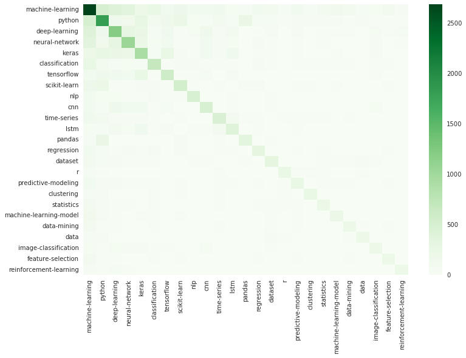

```python
plt.figure(figsize=(12,8))
sns.heatmap(relations_most_used, cmap="Greens", annot=False)
```

Another shortcoming of this attempt is that it only looks at relations between pairs of tags and not between multiple groups of tags. For example, it could be the case that when used together, dataset and scikit-learn have a "strong" relation to pandas, but each by itself doesn't.

```python
all_q = pd.read_csv("all_questions.csv", parse_dates=["CreationDate"])
```

cleaning tags

```python
all_q["Tags"] = all_q["Tags"].str.replace("^<|>$", "").str.split("><")
```

The definition of what constitutes a deep learning tag we'll use is: a tag that belongs to the list ["lstm", "cnn", "scikit-learn", "tensorflow", "keras", "neural-network", "deep-learning"].

This list was obtained by looking at all the tags in most_used and seeing which ones had any relation to deep learning.

create a function that assigns 1 to deep learning questions and 0 otherwise; and we use it.

```python
def class_deep_learning(tags):
    for tag in tags:
        if tag in ["lstm", "cnn", "scikit-learn", "tensorflow",
                   "keras", "neural-network", "deep-learning"]:
            return 1
    return 0
```

```python
all_q["DeepLearning"] = all_q["Tags"].apply(class_deep_learning)
```

```python
all_q.sample(5)
```

|  | Id | CreationDate | Tags | DeepLearning |
| --- | --- | --- | --- | --- |
| 17620 | 53995 | 2019-06-18 08:09:18 | [machine-learning, neural-network, deep-learni... | 1 |
| 14034 | 52450 | 2019-05-23 09:22:35 | [scikit-learn, logistic-regression] | 1 |
| 5224 | 39364 | 2018-10-08 14:59:44 | [python, deep-learning, numpy] | 1 |
| 16947 | 11614 | 2016-05-06 09:21:39 | [machine-learning] | 0 |
| 21277 | 36215 | 2018-07-30 16:30:20 | [neural-network, deep-learning] | 1 |

```python
all_q = all_q[all_q["CreationDate"].dt.year < 2020]
```

create a column that identifies the quarter in which a question was asked.

```python
def fetch_quarter(datetime):
    year = str(datetime.year)[-2:]
    quarter = str(((datetime.month-1) // 3) + 1)
    return "{y}Q{q}".format(y=year, q=quarter)

all_q["Quarter"] = all_q["CreationDate"].apply(fetch_quarter)
```

```python
all_q.head()
```

|  | Id | CreationDate | Tags | DeepLearning | Quarter |
| --- | --- | --- | --- | --- | --- |
| 0 | 45416 | 2019-02-12 00:36:29 | [python, keras, tensorflow, cnn, probability] | 1 | 19Q1 |
| 1 | 45418 | 2019-02-12 00:50:39 | [neural-network] | 1 | 19Q1 |
| 2 | 45422 | 2019-02-12 04:40:51 | [python, ibm-watson, chatbot] | 0 | 19Q1 |
| 3 | 45426 | 2019-02-12 04:51:49 | [keras] | 1 | 19Q1 |
| 4 | 45427 | 2019-02-12 05:08:24 | [r, predictive-modeling, machine-learning-mode... | 0 | 19Q1 |

group by quarter and:

- Count the number of deep learning questions.
- Count the total number of questions.
- Compute the ratio between the two numbers above.

```python
quarterly = all_q.groupby('Quarter').agg({"DeepLearning": ['sum', 'size']})
quarterly.columns = ['DeepLearningQuestions', 'TotalQuestions']
quarterly["DeepLearningRate"] = quarterly["DeepLearningQuestions"]\
                                /quarterly["TotalQuestions"]
quarterly.reset_index(inplace=True)
quarterly.sample(5)
```

|  | Quarter | DeepLearningQuestions | TotalQuestions | DeepLearningRate |
| --- | --- | --- | --- | --- |
| 17 | 18Q3 | 685 | 1512 | 0.453042 |
| 12 | 17Q2 | 226 | 647 | 0.349304 |
| 18 | 18Q4 | 531 | 1294 | 0.410355 |
| 2 | 14Q4 | 21 | 216 | 0.097222 |
| 8 | 16Q2 | 109 | 518 | 0.210425 |

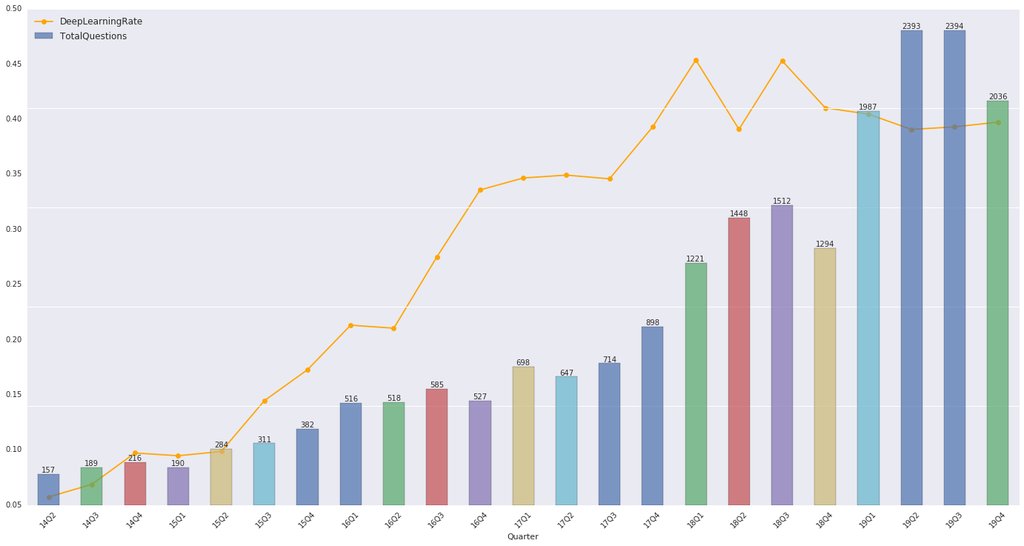

```python
ax1 = quarterly.plot(x="Quarter", y="DeepLearningRate",
                    kind="line", linestyle="-", marker="o", color="orange",
                    figsize=(24,12)
                    )

ax2 = quarterly.plot(x="Quarter", y="TotalQuestions",
                     kind="bar", ax=ax1, secondary_y=True, alpha=0.7, rot=45)

for idx, t in quarterly["TotalQuestions"].iteritems():
    ax2.text(idx, t, str(t), ha="center", va="bottom")
xlims = ax1.get_xlim()

ax1.get_legend().remove()

handles1, labels1 = ax1.get_legend_handles_labels()
handles2, labels2 = ax2.get_legend_handles_labels()
ax1.legend(handles=handles1 + handles2,
           labels=labels1 + labels2,
           loc="upper left", prop={"size": 12})


for ax in (ax1, ax2):
    for where in ("top", "right"):
        ax.spines[where].set_visible(False)
        ax.tick_params(right=False, labelright=False)
```

It seems that deep learning questions was a high-growth trend since the start of DSSE and it looks like it is plateauing. There is no evidence to suggest that interest in deep learning is decreasing and so we maintain our previous idea of proposing that we create deep learning content.